Saltar al contenido

D&C**Algoritmos visuales**Levitin · capítulo 5

Lectura Levitin · Semana 4

# Dividir y *conquistar*

Divide un problema en subproblemas del mismo tipo, resuélvelos —a menudo en paralelo— y combina sus respuestas. Explora cómo esta idea ordena, recorre árboles, acelera productos y resuelve geometría.

Capítulo 5

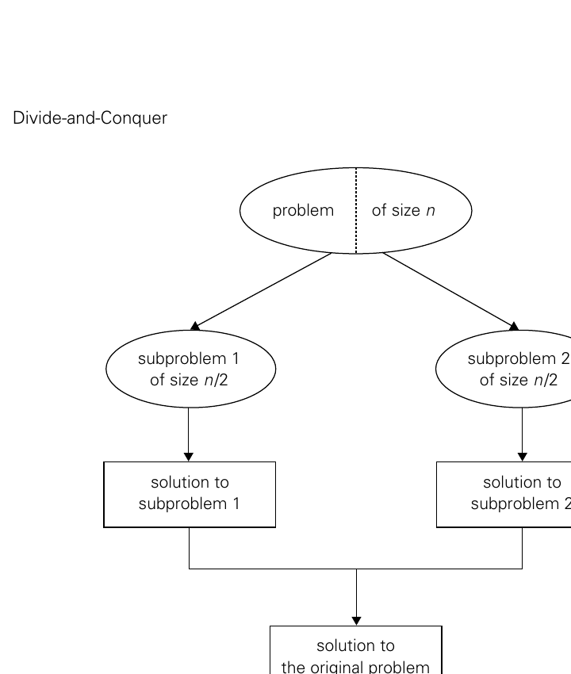

Figura 5.1: dividir, resolver dos subproblemas y combinar sus soluciones.

Modelo de análisis

## ¿Quién domina la recurrencia?

Compara el crecimiento del trabajo recursivo aT(n/b) con el trabajo de dividir y combinar f(n)=Θ(nᵈ).

Explorador interactivoSubproblemas a: 2Factor b: 2Exponente d de f(n): 1

a < bᵈ**Combinar domina**

Θ(nᵈ)

a = bᵈ**Equilibrio**

Θ(nᵈ log n)

a > bᵈ**Recursión domina**

Θ(n^(log_b a))

**Trabajo estimado por niveles**

[figure not shown]

La recurrencia general es T(n)=aT(n/b)+f(n).

### Ejemplos del capítulo

**Mergesort:** 2T(n/2)+Θ(n) → Θ(n log n).

**Karatsuba:** 3T(n/2)+Θ(n) → Θ(n^1.585).

**Strassen:** 7T(n/2)+Θ(n²) → Θ(n^2.807).

**Par cercano:** 2T(n/2)+Θ(n) → Θ(n log n).

Ordenamiento

## Divide por posición o por valor

Mergesort divide inmediatamente y trabaja al combinar. Quicksort trabaja al particionar y luego no necesita combinar.

Laboratorio 01Arreglo

Separamos el arreglo hasta obtener casos base de un elemento.

T(n)=2T(n/2)+Θ(n)  
⇒ Θ(n log n)

**Estado inicial**Dividir

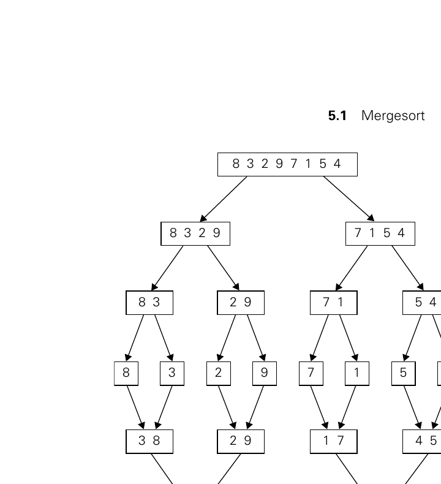

Figura 5.2: el arreglo se divide hasta elementos individuales y luego se fusiona ordenadamente.

### Fusión con dos punteros

Compara las primeras claves pendientes de B y C, copia la menor y avanza solo ese puntero.

**Tiempo:** Θ(n log n) en todos los casos.

**Ventaja:** estable. **Costo:** Θ(n) memoria auxiliar.

Laboratorio 02Arreglo

El primer elemento del subarreglo actúa como pivote.

particionar A[l..r]  
quicksort A[l..s−1]  
quicksort A[s+1..r]

**Instancia completa**Pivote inicial

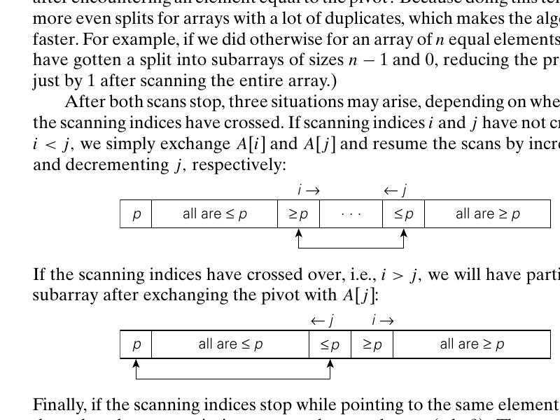

La partición de Hoare escanea desde ambos extremos y coloca el pivote en su posición final.

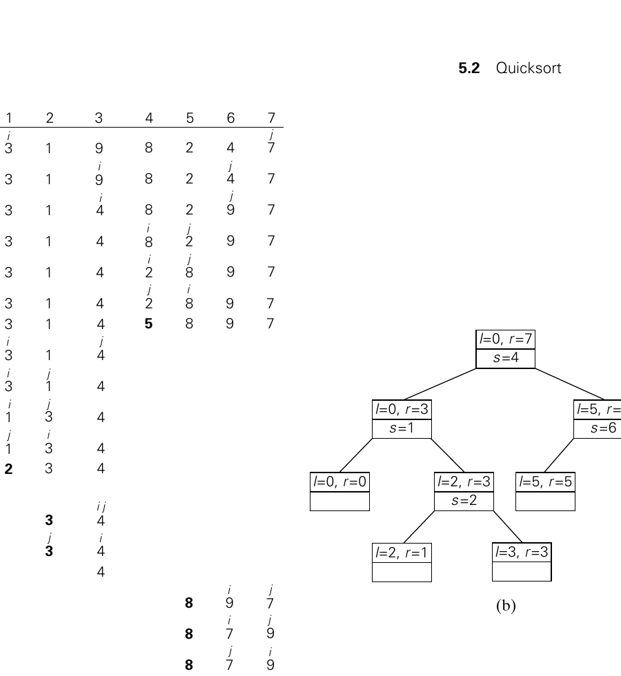

Figura 5.3: transformaciones del arreglo y árbol de llamadas recursivas.

| Aspecto | Mergesort | Quicksort |
| --- | --- | --- |
| **División** | Por posición, inmediata | Por valor, mediante partición |
| **Combinación** | Fusión lineal | No necesita |
| **Tiempo** | Θ(n log n) siempre | Promedio Θ(n log n); peor Θ(n²) |
| **Espacio** | Θ(n) auxiliar | Pila; puede limitarse a O(log n) |
| **Estabilidad** | Sí | No |
| **Fortaleza** | Rendimiento predecible y archivos externos | Muy rápido en memoria con entradas aleatorias |

⚖

**La ubicación del trabajo cambia**

Mergesort divide gratis y paga al combinar; quicksort paga al dividir y combina gratis.

Estructuras recursivas

## Raíz, izquierda, derecha

Un árbol binario ya viene dividido en dos subproblemas del mismo tipo. Los recorridos cambian únicamente el momento en que se visita la raíz.

Laboratorio 03Recorrido

**Altura:** max(altura izquierda, altura derecha)+1 = 3.

[figure not shown]

Figura 5.6: preorden, inorden y postorden sobre el mismo árbol.

### Conteo exacto

Si el árbol tiene n nodos internos, su extensión tiene n+1 nodos externos.

El algoritmo de altura ejecuta **n** sumas y **2n+1** verificaciones de árbol vacío.

Height(∅)=−1  
Height(T)=max(Height(Tᵢ),Height(Tᵣ))+1

Álgebra

## Menos multiplicaciones, más sumas

Karatsuba reemplaza cuatro productos de mitades por tres. Strassen reemplaza ocho productos de bloques por siete. La mejora local cambia el exponente global.

Número aNúmero b

z₂=a₁b₁  
z₀=a₀b₀  
z₁=(a₁+a₀)(b₁+b₀)−z₂−z₀  
ab=z₂·10²ᵐ+z₁·10ᵐ+z₀

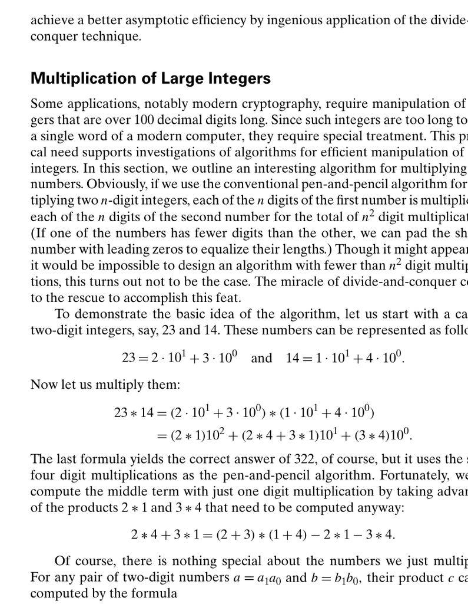

Sección 5.4: el producto cruzado se recupera con una tercera multiplicación.

### A × B

7 multiplicaciones

**Matriz A**

**Matriz B**

**Resultado C**

### Productos intermedios

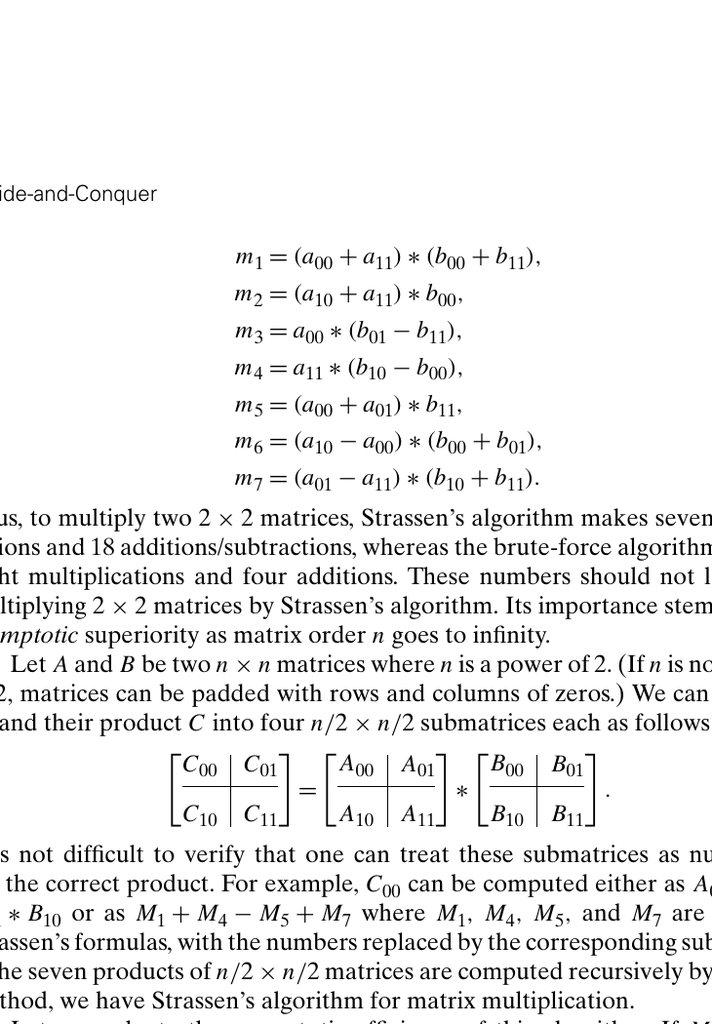

Strassen reduce 8 multiplicaciones escalares a 7, a cambio de más sumas y restas.

Geometría computacional

## Divide el plano

La combinación inteligente evita comparar todas las parejas o probar todos los lados posibles.

Laboratorio 06Puntos: 12

d=min(dᵢ,dᵣ)  
examinar |x−m|<d  
⇒ Θ(n log n)

**Plano cartesiano**Buscando…

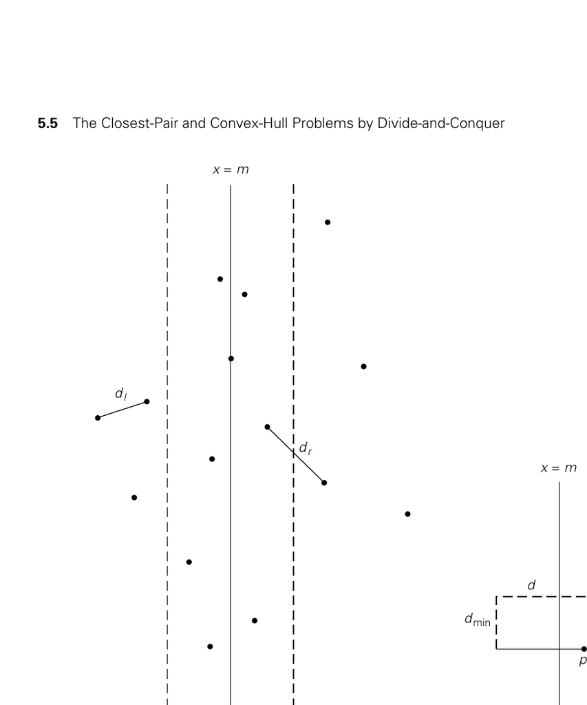

Figura 5.7: tras resolver ambas mitades solo se revisa una franja de ancho 2d.

### La idea decisiva

El par óptimo podría cruzar la línea divisoria. Sin embargo, cada punto de la franja solo necesita compararse con unos pocos sucesores en orden y.

Con preordenamiento por x e y, dividir y combinar cuesta Θ(n) por nivel.

Laboratorio 07Puntos: 15

elegir pₘₐₓ más lejano  
descartar interior del triángulo  
repetir en dos lados

**Construcción de la envolvente**0 extremos

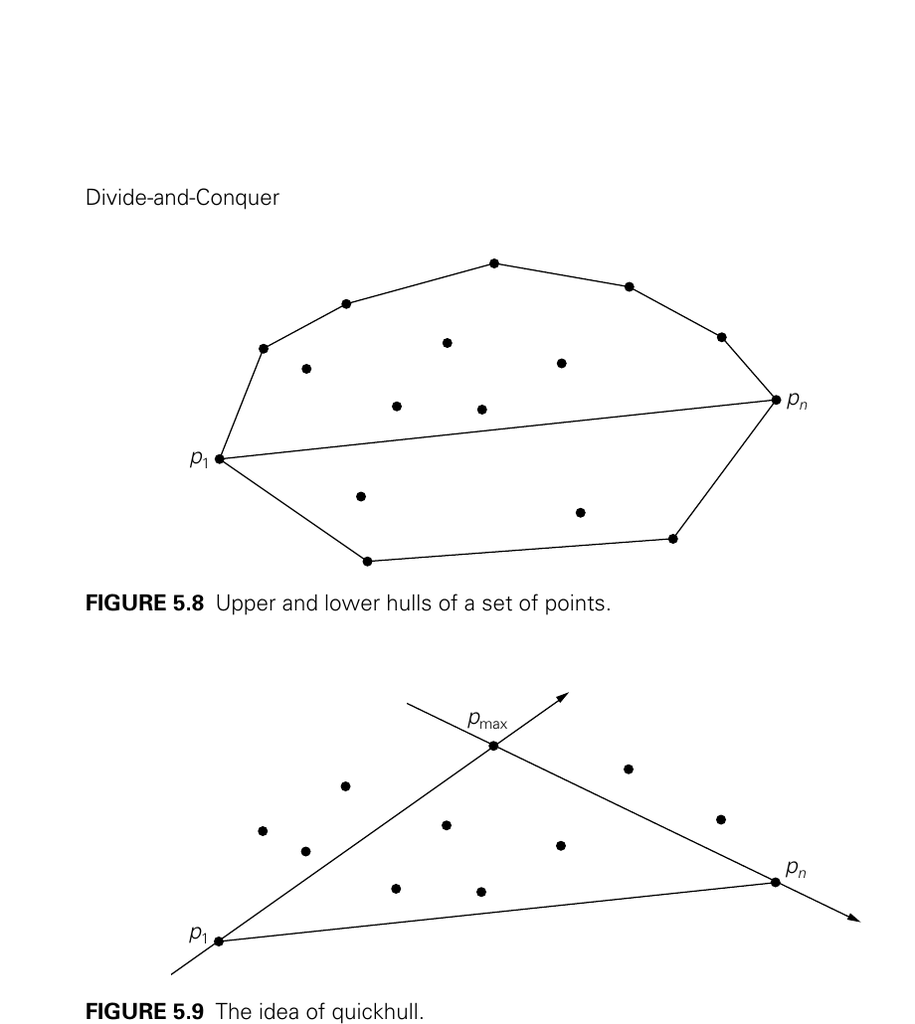

Figuras 5.8 y 5.9: pmax es extremo y el triángulo interior puede descartarse.

### Paralelo con quicksort

Los puntos más alejados actúan como pivotes geométricos. Cada extremo nuevo divide el conjunto restante en dos subproblemas.

**Promedio esperado:** lineal bajo distribución uniforme. **Peor caso:** Θ(n²).

Evaluación formativa

## Divide la pregunta

Diez preguntas conectan la estructura de la recursión, el Teorema Maestro y los algoritmos del capítulo.

Pregunta 1 de 10

Selecciona una respuesta.

### Progreso

**0**correctas

Una pregunta grande, diez subproblemas.